3rd Next Available Tip Sheet Matthew Moreno Updated: 2022-08-08

# *Why the 3rd Next Available?*

Patient accessibility is crucial and the best way to measure this is by the ability of patients to see a provider within a reasonable period of time.

The 3rd next available appointment is a industry standard, as it is a more accurate representation of accessibility versus the 1st next available appointment which can be easily skewed by cancellations or other last minute openings.

## *Methodology*

### 1. All appointment blocks have been classified into 4 primary groups

- **NEW**
- **OTHER**
- **RETURN**
- **TELEHEALTH**

Same day block types have been excluded to produce the best representation of patient access to care.

To view the exact classification of each block please see **Appendix A**

### 2. Once the classification is complete the 3rd Next Available appointment is found for each department and each of the four **Block Types**

The flow chart below shows a simplified view of the process.

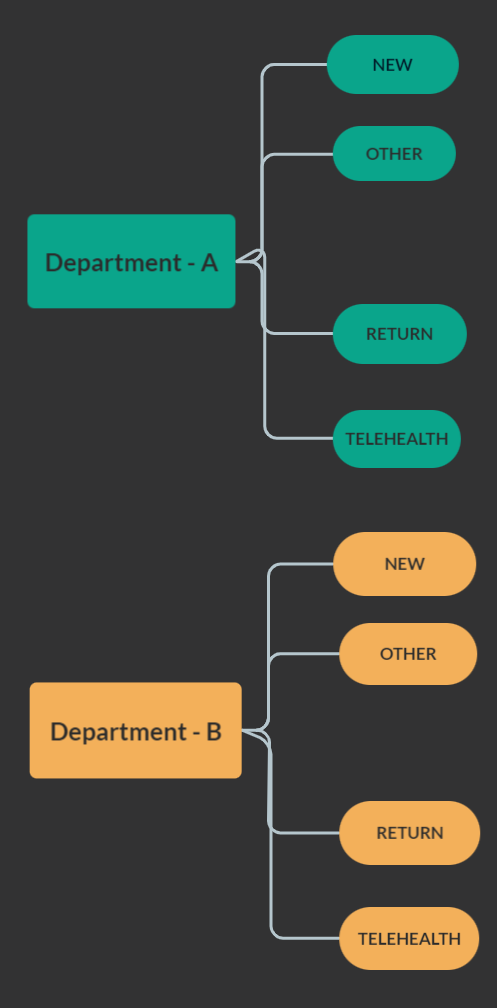

### *Note*

If a department & block combination does **not** have a 3rd Next available appointment a **∞** symbol will be shown.

# *Example A*

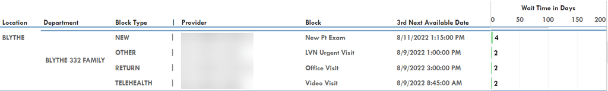

In this example for **Blythe 332 Family Medicine** the department has a $3rd$ Next Available appointment for each **Block Type**

| Block Type | Block | Appointment Date | Wait Time in Days |
| --- | --- | --- | --- |
| NEW | New Pt Exam | 8/11/2022 1:15 PM | 4 |
| OTHER | LVN Urgent Visit | 8/09/2022 1:00 PM | 2 |
| RETURN | Office Visit | 8/09/2022 3:00 PM | 2 |
| TELEHEALTH | Video Visit | 8/09/2022 8:45 AM | 2 |

# *Example B*

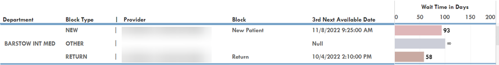

| Block Type | Block | Appointment Date | Wait Time in Days |
| --- | --- | --- | --- |
| NEW | New Patient | 11/08/2022 9:25 AM | 93 |
| OTHER |  |  | **∞** |
| RETURN | Return | 10/04/2022 2:10 PM | 58 |

- The **TELEHEALTH** block type is not shown since **Barstow Internal Med** does not have any Telehealth appointment blocks.
- The block type of **OTHER** has no 3rd Next available appointment thus a wait time appears as **∞**

# *Appendix*

## *A)*

| Block | Block Type |
| --- | --- |
| 1wk ReOB | RETURN |
| Acute | OTHER |
| ADULT ED DISCHARGE | OTHER |
| Arthritis Series | OTHER |
| Basic Dental Visit | RETURN |
| BH MAT NEW | NEW |
| BH MAT RETURN | RETURN |
| BH MAT Shared Visit | OTHER |
| BH MED MGMT NEW | NEW |
| BH MED MGMT RETURN | RETURN |
| BH New | NEW |
| BH RD EST | OTHER |
| BH RD NEW | NEW |
| BH Return Visit | RETURN |
| BH-DM | OTHER |
| BH-IC NEW | NEW |
| BH-IC RETURN | RETURN |
| BH-SC | OTHER |
| Colpo/LARC/EMB | RETURN |
| CRC Established | RETURN |
| CRC New Patient | NEW |
| Dental Exam Visit | RETURN |
| Dental OV Est | RETURN |
| Dental OV New | NEW |
| Denture Repair | OTHER |
| ENT PEDS PT | OTHER |
| Epilepsy New | NEW |
| Epilepsy Return | RETURN |
| FM PEDS OFFICE VISIT | OTHER |
| FM-HWL | OTHER |

[output cut: 113 more lines]